# Global Power Plants Data Exploration

## Introduction

### Global Power Plant Database:

The Global Power Plant Database is an open-source open-access dataset of grid-scale (1 MW and greater) electricity generating facilities operating across the world. The Database currently contains nearly 35000 power plants in 167 countries, representing about 72% of the world's capacity. The dataset is available in this [Link.](https://datasets.wri.org/dataset/globalpowerplantdatabase)

The csv file of the Global Power Plant Database contains 36 columns (fields):

- `country` (text): 3 character country code corresponding to the ISO 3166-1 alpha-3 specification.
- `country_long` (text): longer form of the country designation
- `name` (text): name or title of the power plant, generally in Romanized form
- `gppd_idnr` (text): 10 or 12 character identifier for the power plant
- `capacity_mw` (number): electrical generating capacity in megawatts (Here is a [link](https://www.energy.gov/ne/articles/what-generation-capacity) for more about capacity and generation)
- `latitude` (number): geolocation in decimal degrees; WGS84 (EPSG:4326)
- `longitude` (number): geolocation in decimal degrees; WGS84 (EPSG:4326)
- `primary_fuel` (text): energy source used in primary electricity generation or export
- `other_fuel1` (text): energy source used in electricity generation or export
- `other_fuel2` (text): energy source used in electricity generation or export
- `other_fuel3` (text): energy source used in electricity generation or export
- `commissioning_year` (number): year of plant operation, weighted by unit-capacity when data is available
- `owner` (text): majority shareholder of the power plant, generally in Romanized form
- `source` (text): entity reporting the data; could be an organization, report, or document, generally in Romanized form
- `url` (text): web document corresponding to the `source` field
- `geolocation_source` (text): attribution for geolocation information
- `wepp_id` (text): a reference to a unique plant identifier in the widely-used PLATTS-WEPP database.
- `year_of_capacity_data` (number): year the capacity information was reported
- `generation_gwh_2013` (number): electricity generation in gigawatt-hours reported for the year 2013
- `generation_gwh_2014` (number): electricity generation in gigawatt-hours reported for the year 2014
- `generation_gwh_2015` (number): electricity generation in gigawatt-hours reported for the year 2015
- `generation_gwh_2016` (number): electricity generation in gigawatt-hours reported for the year 2016
- `generation_gwh_2017` (number): electricity generation in gigawatt-hours reported for the year 2017
- `generation_gwh_2018` (number): electricity generation in gigawatt-hours reported for the year 2018
- `generation_gwh_2019` (number): electricity generation in gigawatt-hours reported for the year 2019
- `generation_data_source` (text): attribution for the reported generation information
- `estimated_generation_gwh_2013` (number): estimated electricity generation in gigawatt-hours for the year 2013.
- `estimated_generation_gwh_2014` (number): estimated electricity generation in gigawatt-hours for the year 2014.
- `estimated_generation_gwh_2015` (number): estimated electricity generation in gigawatt-hours for the year 2015.
- `estimated_generation_gwh_2016` (number): estimated electricity generation in gigawatt-hours for the year 2016.
- `estimated_generation_gwh_2017` (number): estimated electricity generation in gigawatt-hours for the year 2017.
- `estimated_generation_note_2013` (text): label of the model/method used to estimate generation for the year 2013.
- `estimated_generation_note_2014` (text): label of the model/method used to estimate generation for the year 2014.
- `estimated_generation_note_2015` (text): label of the model/method used to estimate generation for the year 2015.
- `estimated_generation_note_2016` (text): label of the model/method used to estimate generation for the year 2016.
- `estimated_generation_note_2017` (text): label of the model/method used to estimate generation for the year 2017.

**Notes:**

1) Estimation of annual generation is performed by separate models/methods depending on the attributes of the plant, primarily the fuel type, but also whether certain fields contain values or are unknown.

2) Generation is provided at the year scale for the years 2013-2019.

3) The fields `estimated_generation_note_YYYY` exist to communicate the estimation method that is used for each plant, for each year:

## Preliminary Wrangling

```python
# import all packages and set plots to be embedded inline
import numpy as np
import pandas as pd
import matplotlib.pyplot as plt
import seaborn as sb

%matplotlib inline
```

```python
#loading the data
plants = pd.read_csv('global_power_plant_database.csv')
```

```python
plants.columns
```

```
Index(['country', 'country_long', 'name', 'gppd_idnr', 'capacity_mw',
       'latitude', 'longitude', 'primary_fuel', 'other_fuel1', 'other_fuel2',
       'other_fuel3', 'commissioning_year', 'owner', 'source', 'url',
       'geolocation_source', 'wepp_id', 'year_of_capacity_data',
       'generation_gwh_2013', 'generation_gwh_2014', 'generation_gwh_2015',
       'generation_gwh_2016', 'generation_gwh_2017', 'generation_gwh_2018',
       'generation_gwh_2019', 'generation_data_source',
       'estimated_generation_gwh_2013', 'estimated_generation_gwh_2014',
       'estimated_generation_gwh_2015', 'estimated_generation_gwh_2016',
       'estimated_generation_gwh_2017', 'estimated_generation_note_2013',
       'estimated_generation_note_2014', 'estimated_generation_note_2015',
       'estimated_generation_note_2016', 'estimated_generation_note_2017'],
      dtype='object')
```

```python
#An overview of the data
print(plants.shape)
print(plants.info())
```

```
(34936, 36)
<class 'pandas.core.frame.DataFrame'>
RangeIndex: 34936 entries, 0 to 34935
Data columns (total 36 columns):
 #   Column                          Non-Null Count  Dtype
---  ------                          --------------  -----
 0   country                         34936 non-null  object
 1   country_long                    34936 non-null  object
 2   name                            34936 non-null  object
 3   gppd_idnr                       34936 non-null  object
 4   capacity_mw                     34936 non-null  float64
 5   latitude                        34936 non-null  float64
 6   longitude                       34936 non-null  float64
 7   primary_fuel                    34936 non-null  object
 8   other_fuel1                     1944 non-null   object
```

[output cut: 30 more lines]

> There is a lot of variables with a huge number of Nan values, specially the **generation_gwh_20xx** variables (almost 3 quarters of the dataset).

```python
plants.head()
```

|  | country | country_long | name | gppd_idnr | capacity_mw | latitude | longitude | primary_fuel | other_fuel1 | other_fuel2 | ... | estimated_generation_gwh_2013 | estimated_generation_gwh_2014 | estimated_generation_gwh_2015 | estimated_generation_gwh_2016 | estimated_generation_gwh_2017 | estimated_generation_note_2013 | estimated_generation_note_2014 | estimated_generation_note_2015 | estimated_generation_note_2016 | estimated_generation_note_2017 |
| --- | --- | --- | --- | --- | --- | --- | --- | --- | --- | --- | --- | --- | --- | --- | --- | --- | --- | --- | --- | --- | --- |
| 0 | AFG | Afghanistan | Kajaki Hydroelectric Power Plant Afghanistan | GEODB0040538 | 33.0 | 32.322 | 65.1190 | Hydro | NaN | NaN | ... | 123.77 | 162.90 | 97.39 | 137.76 | 119.50 | HYDRO-V1 | HYDRO-V1 | HYDRO-V1 | HYDRO-V1 | HYDRO-V1 |
| 1 | AFG | Afghanistan | Kandahar DOG | WKS0070144 | 10.0 | 31.670 | 65.7950 | Solar | NaN | NaN | ... | 18.43 | 17.48 | 18.25 | 17.70 | 18.29 | SOLAR-V1-NO-AGE | SOLAR-V1-NO-AGE | SOLAR-V1-NO-AGE | SOLAR-V1-NO-AGE | SOLAR-V1-NO-AGE |
| 2 | AFG | Afghanistan | Kandahar JOL | WKS0071196 | 10.0 | 31.623 | 65.7920 | Solar | NaN | NaN | ... | 18.64 | 17.58 | 19.10 | 17.62 | 18.72 | SOLAR-V1-NO-AGE | SOLAR-V1-NO-AGE | SOLAR-V1-NO-AGE | SOLAR-V1-NO-AGE | SOLAR-V1-NO-AGE |
| 3 | AFG | Afghanistan | Mahipar Hydroelectric Power Plant Afghanistan | GEODB0040541 | 66.0 | 34.556 | 69.4787 | Hydro | NaN | NaN | ... | 225.06 | 203.55 | 146.90 | 230.18 | 174.91 | HYDRO-V1 | HYDRO-V1 | HYDRO-V1 | HYDRO-V1 | HYDRO-V1 |
| 4 | AFG | Afghanistan | Naghlu Dam Hydroelectric Power Plant Afghanistan | GEODB0040534 | 100.0 | 34.641 | 69.7170 | Hydro | NaN | NaN | ... | 406.16 | 357.22 | 270.99 | 395.38 | 350.80 | HYDRO-V1 | HYDRO-V1 | HYDRO-V1 | HYDRO-V1 | HYDRO-V1 |

5 rows × 36 columns

```python
#Check for duplicates

plants.gppd_idnr.duplicated().sum()
```

```
0
```

```python
# Changing data types for year columns
plants.loc[plants['commissioning_year'].notna(),'commissioning_year'] = plants.loc[plants['commissioning_year'].notna(),'commissioning_year'].astype(int).astype(str)
plants.loc[plants['year_of_capacity_data'].notna(),'year_of_capacity_data'] = plants.loc[plants['year_of_capacity_data'].notna(),'year_of_capacity_data'].astype(int).astype(str)
```

```python
#checking result
plants[plants['year_of_capacity_data'].notna()]['year_of_capacity_data'].unique()
```

```
array(['2017', '2015', '2013', '2016', '2014', '2000', '2012', '2009',
       '2010', '2019', '2018'], dtype=object)
```

> The years 2001-2008 and 2011 don't exist, not surprising if we look at the Nan's values count.

```python
plants.describe()
```

|  | capacity_mw | latitude | longitude | generation_gwh_2013 | generation_gwh_2014 | generation_gwh_2015 | generation_gwh_2016 | generation_gwh_2017 | generation_gwh_2018 | generation_gwh_2019 | estimated_generation_gwh_2013 | estimated_generation_gwh_2014 | estimated_generation_gwh_2015 | estimated_generation_gwh_2016 | estimated_generation_gwh_2017 |
| --- | --- | --- | --- | --- | --- | --- | --- | --- | --- | --- | --- | --- | --- | --- | --- |
| count | 34936.000000 | 34936.000000 | 34936.000000 | 6417.000000 | 7226.000000 | 8203.000000 | 9144.000000 | 9500.000000 | 9637.000000 | 9659.000000 | 16120.000000 | 16503.000000 | 17050.000000 | 17570.000000 | 33138.000000 |
| mean | 163.355148 | 32.816637 | -6.972803 | 592.696107 | 656.863891 | 762.368840 | 693.149763 | 661.834161 | 517.320785 | 423.922436 | 239.112221 | 242.431122 | 235.866067 | 235.695265 | 716.443378 |
| std | 489.636072 | 22.638603 | 78.405850 | 2174.833482 | 2231.464288 | 2533.459828 | 2404.516759 | 2369.296957 | 1975.302686 | 1698.506485 | 1191.258172 | 1285.798297 | 1267.005223 | 1259.559841 | 2484.361200 |
| min | 1.000000 | -77.847000 | -179.977700 | -947.600000 | -989.619000 | -864.428000 | -768.620000 | -934.944000 | -982.622000 | -780.339000 | 1.120000 | 0.870000 | 0.440000 | 0.300000 | 0.000000 |
| 25% | 4.900000 | 29.256475 | -77.641550 | 1.947000 | 2.260000 | 2.664500 | 2.729000 | 2.467000 | 2.242000 | 2.751500 | 8.620000 | 8.680000 | 8.380000 | 8.322500 | 8.180000 |
| 50% | 16.745000 | 39.727750 | -2.127100 | 23.426000 | 23.608500 | 26.142000 | 22.462389 | 17.876500 | 12.530000 | 11.530000 | 27.620000 | 28.250000 | 26.830000 | 27.555000 | 37.590000 |
| 75% | 75.344250 | 46.263125 | 49.502675 | 199.706000 | 226.322250 | 285.862583 | 249.866750 | 214.505150 | 151.117000 | 122.781498 | 106.805000 | 106.980000 | 103.120000 | 107.237500 | 229.565000 |
| max | 22500.000000 | 71.292000 | 179.388700 | 50834.000000 | 32320.917000 | 37433.607000 | 32377.477000 | 36448.643000 | 35136.000000 | 31920.368000 | 48675.060000 | 58470.770000 | 57113.350000 | 60859.730000 | 82810.770000 |

```python
# There is a negative values in the generation_gwh variables, so I'm checking that !!
plants.loc[(plants['generation_gwh_2013'] < 0) | (plants['generation_gwh_2014'] < 0 ) |(plants['generation_gwh_2015'] < 0)
          |(plants['generation_gwh_2016'] < 0)|(plants['generation_gwh_2017'] < 0)|(plants['generation_gwh_2018'] < 0)
          |(plants['generation_gwh_2019'] < 0)].count()[0]
```

```
324
```

```python
#Droping these rows

plants.drop(plants.loc[(plants['generation_gwh_2013'] < 0) | (plants['generation_gwh_2014'] < 0 ) |(plants['generation_gwh_2015'] < 0)
          |(plants['generation_gwh_2016'] < 0)|(plants['generation_gwh_2017'] < 0)|(plants['generation_gwh_2018'] < 0)
          |(plants['generation_gwh_2019'] < 0)].index, inplace= True)
```

Take only data with specific features:

```python
plants = plants.loc[:,['year_of_capacity_data','capacity_mw', 'generation_gwh_2013','generation_gwh_2014','generation_gwh_2015','generation_gwh_2016','generation_gwh_2017','generation_gwh_2018','generation_gwh_2019', 'primary_fuel', 'country_long', 'country', 'commissioning_year', 'other_fuel1', 'other_fuel2','other_fuel3']]
```

### What is the structure of your dataset?

There are 34936 power plants in this dataset with 36 features: 'country', 'country_long', 'name', 'gppd_idnr', 'capacity_mw', 'latitude', 'longitude', 'primary_fuel', 'other_fuel1', 'other_fuel2', 'other_fuel3', 'commissioning_year', 'owner', 'source', 'url', 'geolocation_source', 'wepp_id', 'year_of_capacity_data', 'generation_gwh_2013', 'generation_gwh_2014', 'generation_gwh_2015', 'generation_gwh_2016', 'generation_gwh_2017', 'generation_gwh_2018', 'generation_gwh_2019', 'generation_data_source', 'estimated_generation_gwh_2013', 'estimated_generation_gwh_2014', 'estimated_generation_gwh_2015', 'estimated_generation_gwh_2016', 'estimated_generation_gwh_2017', 'estimated_generation_note_2013', 'estimated_generation_note_2014', 'estimated_generation_note_2015', 'estimated_generation_note_2016', 'estimated_generation_note_2017'. The data is divided between numeric and categorical types. There are some variables indicating informations that might not be a part of this analysis (url, wepp_id, gppd_idnr, longtitude and latitude...etc)

### What is/are the main feature(s) of interest in your dataset?

I'm interested in figuring out the growth of the power generation amoung time and place, also how much each fuel type is used.

### What features in the dataset do you think will help support your investigation into your feature(s) of interest?

I expect that **capacity_mw** and **gereration_gwh's** columns will indentify the quanitity of power used, **year_of_capacity_data** is expected to show the progress, but regarding the missing rows and years in that column, the **commissioning_year** would be useful. Also I can make a use of **primary_fuel** and **other_fuel's** columns to see how much are fuel types used. **country_long** will let me discover places and their relation with power quantity

## Univariate Exploration

I'll start this part by looking at my interesting variables: capacity_mw

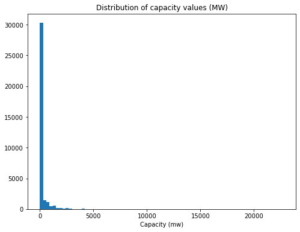

```python
#PLotting a Histogram in order to see distrubtion of numerical variable

bins = np.arange(0, 23000,300)
plt.figure(figsize=[8,6])
plt.hist(data= plants, x = 'capacity_mw', bins = bins);
plt.xlabel('Capacity (mw)')
plt.title('Distribution of capacity values (MW)');
```

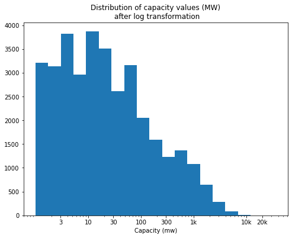

```python
#After using the log scale

#Making a special bin values using decimal logartihm and it's inverse function (power of 10)
log_bin = 0.24
bins = 10 ** np.arange(0, np.log10(plants['capacity_mw'].max())+log_bin, log_bin)

plt.figure(figsize=[8,6])
plt.hist(data= plants, x = 'capacity_mw', bins = bins);
plt.xscale('log')
plt.xticks([3,10, 30, 100, 300, 1000,10000, 20000],[3,10, 30, 100, 300, '1k', '10k', '20k'] )
plt.xlabel('Capacity (mw)')
plt.title('Distribution of capacity values (MW)\n after log transformation');
```

> I'm going to see the percentage of values of capacity less than 2000:

```python
plants.loc[plants['capacity_mw']<= 2000].shape[0]/ plants.shape[0]
```

```
0.9865075696290304
```

After using a log scale, we see that peak at 4 and 10, and it's more obvious that the majority of data is gathered before the value 2000 not 500 as before.

Let's take off the outliers over 2000 mw before continuing:

```python
plants = plants.loc[plants['capacity_mw']<= 2000]
```

```python
plants.shape[0]
```

```
34145
```

Next, we look at the generation_gwh_xxxx columns (just to remind that those columns have a huge number of nan's)

First, I need to drop the negative values in these variables:

```python
#Droping Negative values of generation_gwh columns:

plants.drop(plants.loc[(plants['generation_gwh_2013'] < 0) | (plants['generation_gwh_2014'] < 0 ) |(plants['generation_gwh_2015'] < 0)
          |(plants['generation_gwh_2016'] < 0)|(plants['generation_gwh_2017'] < 0)|(plants['generation_gwh_2018'] < 0)
          |(plants['generation_gwh_2019'] < 0)].index, inplace= True)
```

```python
# Making a function that plots histograms in one Figure
def hists(bin_s = list(), cols = list(), data = pd.DataFrame, trans = False):
    i = 1
    for col in cols:
        plt.subplot(4,2,i)
        plt.hist(data[col], bins = bin_s)
        if trans:
            plt.xscale('log')
        plt.xlabel('201{} power generation (gwh)'.format(i+2))
        i += 1
```

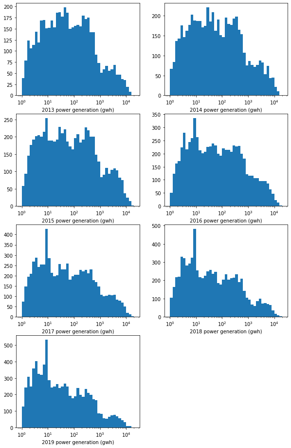

```python
#I'm directly using the log scale

log_bin = 0.1
bins_l = 10 ** np.arange(0, np.log10(plants['generation_gwh_2015'].max())+log_bin, log_bin)
plt.figure(figsize= [10,16])
hists(bin_s = bins_l, cols = ['generation_gwh_2013', 'generation_gwh_2014', 'generation_gwh_2015',
                            'generation_gwh_2016', 'generation_gwh_2017', 'generation_gwh_2018', 'generation_gwh_2019'], data = plants, trans= True)
```

```python
plants[plants['generation_gwh_2013'] < 500].shape[0], plants[plants['generation_gwh_2019'] < 500].shape[0]
```

```
(5232, 8211)
```

These are looking almost like before; right skewed hitograms, it is because relation between the generation of power and capacity. These hitograms are similar and getting more skewed to right against years, this could means that with time moving more plants are less power are made. I would expect all of them to be strongly correlated.

Now, let's see the primary_fuel variable:

```python
#making categories and bar height values for the plot
fuel = plants.groupby('primary_fuel').count()['country'].sort_values(ascending= False)
count_fuel = fuel.values
fuel_type = fuel.index
fuel_type
```

```
Index(['Solar', 'Hydro', 'Wind', 'Gas', 'Oil', 'Coal', 'Biomass', 'Waste',
       'Geothermal', 'Nuclear', 'Storage', 'Other', 'Cogeneration', 'Petcoke',
       'Wave and Tidal'],
      dtype='object', name='primary_fuel')
```

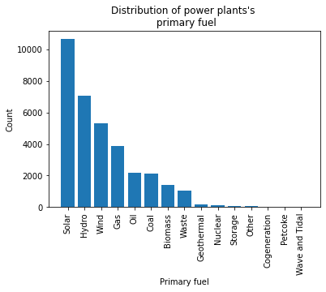

```python
plt.bar(x = fuel_type, height =count_fuel )
plt.xticks(rotation = 90);
plt.xlabel('Primary fuel')
plt.ylabel('Count')
plt.title('Distribution of power plants\'s \n primary fuel')
```

As it seems for the primary fuel, the three most used energy sources are renewable energies, ordered descendingly as Solar, Hydro and Wind energies. Gas, Oil and other fuel sources comes after in order. It's obvious that most of world is heading more to renewable energy sources, specially solar plants. Fossil fuels are also majors in the fuel market. These informations may take more investigation.

I'll move now to other_fuel varialbes:

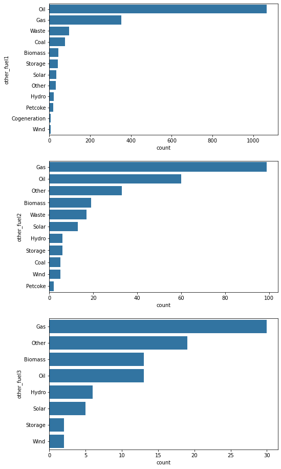

```python
fig, ax = plt.subplots(nrows = 3, figsize = [8, 16])
arr = ['other_fuel1', 'other_fuel2', 'other_fuel3']
default_c = sb.color_palette()[0]
for i in range(len(arr)):
    order = plants.groupby(arr[i]).count()['country'].sort_values(ascending= False).index
    sb.countplot(data = plants, y = arr[i], color = default_c, order= order, ax= ax[i])
```

Most Power plants seems to use Gas and Oil more as another fuel source for generating energy.

Moving to the country variable (**country** or **country_long** is the same):

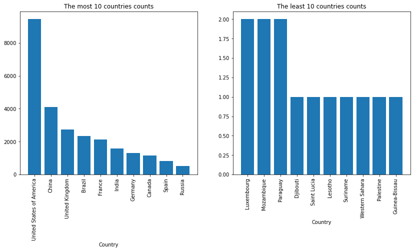

```python
#Select the most 10 frequent countries that use more power plants amoung >160 countries

country = plants.groupby('country_long').count()['country'].sort_values(ascending= False)
most_cntr_v = country[:10].values
least_cntr_v = country[-10:].values
most_cntr_i = country[:10].index
least_cntr_i = country[-10:].index
plt.figure(figsize= [14,6])
plt.subplot(1,2,1)
plt.bar(x = most_cntr_i, height= most_cntr_v)
plt.xticks(rotation = 90)
plt.xlabel('Country')
plt.title('The most 10 countries counts')
plt.subplot(1,2,2)
plt.bar(x = least_cntr_i, height= least_cntr_v)
plt.xticks(rotation = 90)
plt.xlabel('Country')
plt.title('The least 10 countries counts');
```

```python
plants[plants['year_of_capacity_data'].isna()].count()[0]/ plants.shape[0]
```

[output not shown]

```python
print(str(country[:10].sum()/ plants.shape[0]*100) + '%')
```

```
76.50607702445453%
```

In adverse, *Guiniea-Bissau*, *Palestine*, *Suriname* and *Western Sahara* are the countries with the least number of power plants, which is one plant per country.

Let me see the **year_of_capacity_data** variable before I move to bivariate visuals :

```python
#Excluding years under 2000
group_year = plants.groupby('commissioning_year').count()['country'].sort_index()
years = group_year.index
values = group_year.values
years_id = years[years>= '2000']
year_count = group_year[years_id].values
```

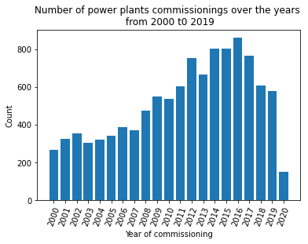

```python
plt.bar(x = years_id, height= year_count)
plt.title('Number of power plants commissionings over the years \n from 2000 t0 2019')
plt.xticks(rotation = 70);
plt.xlabel('Year of commissioning')
plt.ylabel('Count')
```

Number of power plants is increasing over the years, after 2016 we see a chute until 2020. Because the data is recorded until 2019, 2020 actually shouldn't be here.

### Discuss the distribution(s) of your variable(s) of interest. Were there any unusual points? Did you need to perform any transformations?

> The capacity_mw took a big range of values, so I used log scaling to make the distrubtion more obvious. The data looked unimodal, with a lot of peaks at multiple values.

### Of the features you investigated, were there any unusual distributions? Did you perform any operations on the data to tidy, adjust, or change the form of the data? If so, why did you do this?

> In the same variable above, I droped a bunch of outliers over 2000 after looking at the transformed plot to avoid the change that could happens from big values with low count.

## Bivariate Exploration

To begin this section, I'm going to see the correlations between features of this dataset:

```python
Cat_var = ['country_long', 'primary_fuel', 'commissioning_year']
num_var = ['capacity_mw','generation_gwh_2013', 'generation_gwh_2014', 'generation_gwh_2015', 'generation_gwh_2016', 'generation_gwh_2017', 'generation_gwh_2018', 'generation_gwh_2019' ]

#data of only th year 2000 and after
plants_c = plants[plants.commissioning_year.isin(years_id)]
```

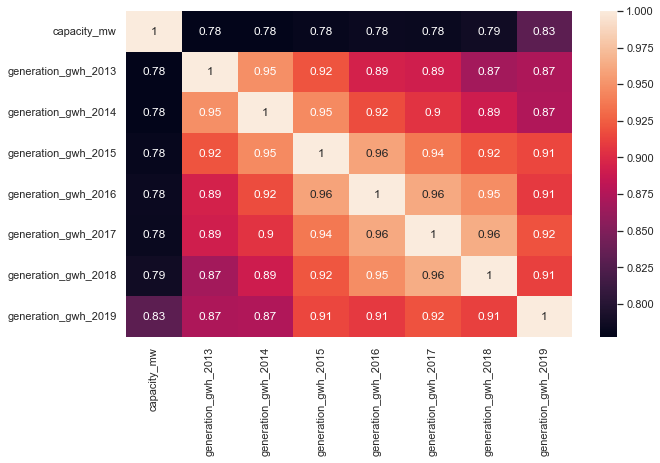

```python
arr_cor = plants[num_var].corr()
sb.set(rc={'figure.figsize':(10,6)})
sb.heatmap(arr_cor, annot=True)
plt.show()
```

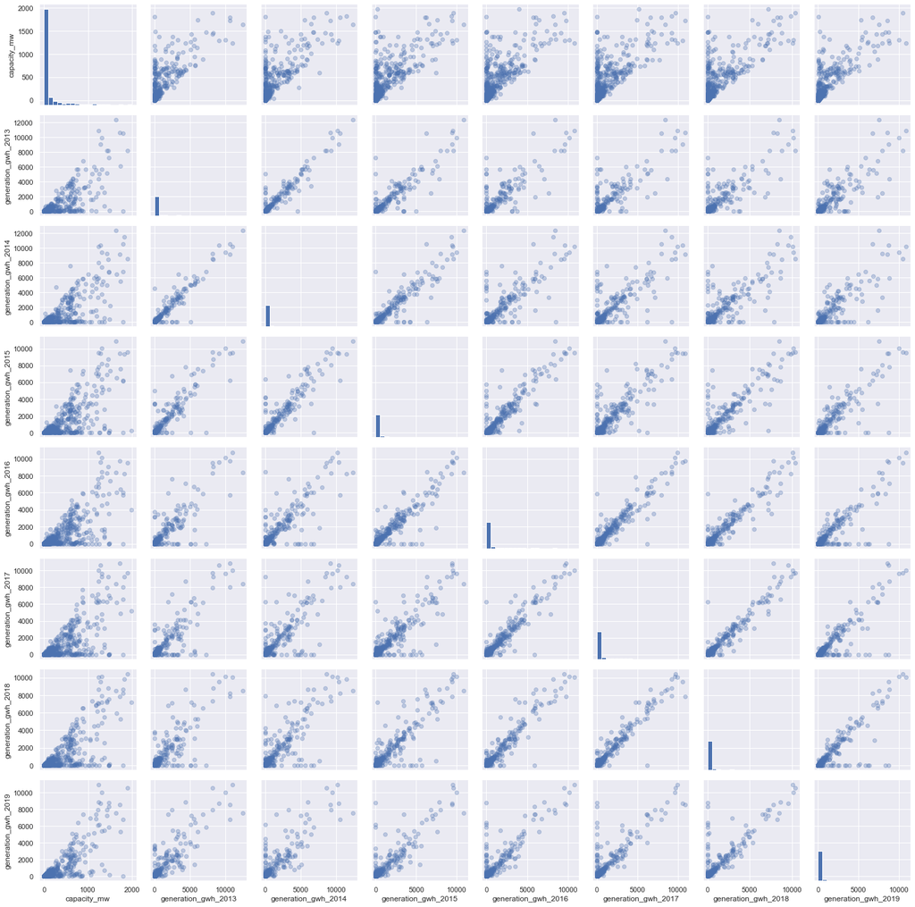

```python
#Chossing a sample and dropping nans
plants_sample = plants.sample(n = 5000)
g = sb.PairGrid(data = plants_sample[num_var])
g.map_diag(plt.hist, bins = 20)
g.map_offdiag(plt.scatter, alpha = .3)
```

```python
plants.groupby('year_of_capacity_data').count()['country']/ plants.shape[0]
```

```
year_of_capacity_data
2000    0.001699
2009    0.000029
2010    0.000029
2012    0.000176
2013    0.000410
2014    0.000586
2015    0.008230
2016    0.022785
2017    0.097906
2018    0.002138
2019    0.288886
Name: country, dtype: float64
```

As I expect, all the variables below are highly correlated to each other. Obviously capacity would be correlated with generation, regarding the different shapes from others. It is the capacity being the maximum possible power in one hour ($MW$) and power generation at best conditions equals *capacity $*$ time* ($MWH$), so in other conditions generation will be less than maximum.

Maximum correlation between capacity and generation is at 2019. It could be that most capacity data was recorded in 2019 (28% of the data). For generations across each other, the strongest correlation is between every two ordered variable by year. Maybe that shows how the generation of power in each year is consistent and increasing upon years regulary at the same time.

Next I'll see relation between capacity and primary_fuel + country_long:

```python
#Choose only 10 countries (amoung ~160) with the highest capacity mean
bar_order = plants.groupby('primary_fuel')['capacity_mw'].mean().sort_values(ascending = False).index
high_cp = plants.groupby('country_long')['capacity_mw'].mean().sort_values(ascending= False)[:10]
high_cp = high_cp.index
plants_box = plants[plants['country_long'].isin(high_cp)]
cap_year_mean = plants_c.groupby('commissioning_year')['capacity_mw'].mean().sort_index().values
```

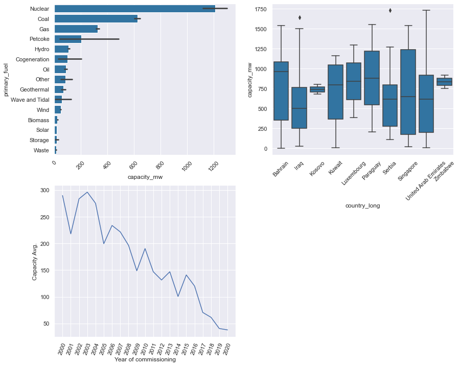

```python
# Using primary_fuel order from previous

plt.figure(figsize= [14,12])
plt.subplot(221)
sb.barplot(data= plants, y = 'primary_fuel', x = 'capacity_mw', color= default_c, order= bar_order)
plt.xticks(rotation = 45)
plt.subplot(222)
sb.boxplot(data = plants_box, x = 'country_long', y = 'capacity_mw', color= default_c)
plt.xticks(rotation = 45)
plt.subplot(223)
plt.errorbar(x = years_id, y = cap_year_mean)
plt.xticks(rotation = 70)
plt.xlabel('Year of commissioning')
plt.ylabel('Capacity Avg.')
```

Capacity average is decreasing over years. That's probably due to diversity of fuel kinds with low capacity factor (or payoff of energy).

Nuclear fuel has the highest average, followed by coal, gas, petcoke and hydro, contrary to solar and wind. This may tells about the relation between fuel type and capacity factor.

Paraguay and Luxembourg have the highest average after Bahrain, even that they have 2 power plants. Maybe they're using a fuel like nuclear with high factor. The small range of values in Zimbabwe and Kosovo may shows them using a few a types of fuel. The opposite to The Arab countries + Serbia and Singapore, they might use much more different of fuel types.

Next I'll look at categories relations:

```python
#Choose countries with most high counts
count_pf = plants[plants['country_long'].isin(most_cntr_i)].groupby(['primary_fuel', 'country_long']).size().reset_index(name = 'count')
count_pf = count_pf.pivot(index= 'country_long', columns= 'primary_fuel', values= 'count')
```

```python
most_cntr_i
```

```
Index(['United States of America', 'China', 'United Kingdom', 'Brazil',
       'France', 'India', 'Germany', 'Canada', 'Spain', 'Russia'],
      dtype='object', name='country_long')
```

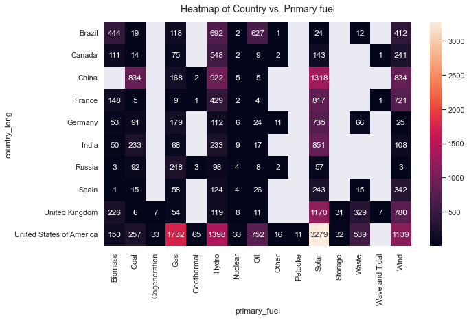

```python
sb.heatmap(count_pf, annot= True, fmt = '.0f')
plt.title('Heatmap of Country vs. Primary fuel', fontsize = 14, y = 1.025)
```

Solar is obviously has the most count. USA, China and UK has more solars. Hydro is has a big count in China and USA. China has a big frequency at coal and wind, and a big count of gas, wind and oil in USA.

Next, I wanna see the relation between capacity_mw and number of power plants:

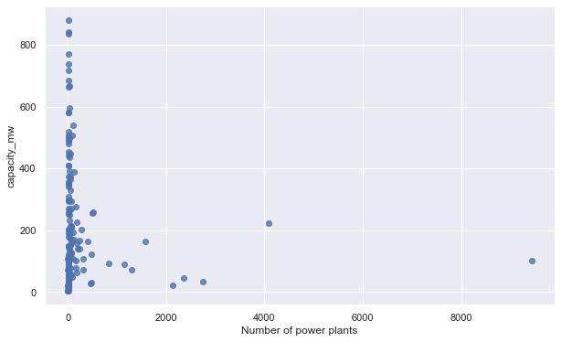

```python
sb.regplot(x = plants.groupby('country_long').count()['country'], y = plants.groupby('country_long')['capacity_mw'].mean(), fit_reg=False
)
plt.xlabel('Number of power plants')
```

It doesn't seem like there is any relation in this plot.

### Talk about some of the relationships you observed in this part of the investigation. How did the feature(s) of interest vary with other features in the dataset?

Surely I would expect a strong relation between time and capacity, taking only plants from 2000 with. Same between the plants number capacity comparing with barchart from before, where I couldn't see this relation in the regression plot.

### Did you observe any interesting relationships between the other features (not the main feature(s) of interest)?

The generation between a year and the next is almost the same with regular increasings.

Wind and solar energies is moslty used in power plants in the USA, China, France and UK. China, Brazil and USA has big number of Hydro plants. Brazil and USA use more oil plants than any other, and preceding one depends on gas fuel more than any other after solar.

## Multivariate Exploration

First, let's see relation between countries, primary_fuel and capacity:

```python
#Choose countries with most high counts
mean_pf = plants[plants['country_long'].isin(most_cntr_i)].groupby(['primary_fuel', 'country_long'])['capacity_mw'].mean().reset_index(name = 'count')
mean_pf = mean_pf.pivot(index= 'country_long', columns= 'primary_fuel', values= 'count')
```

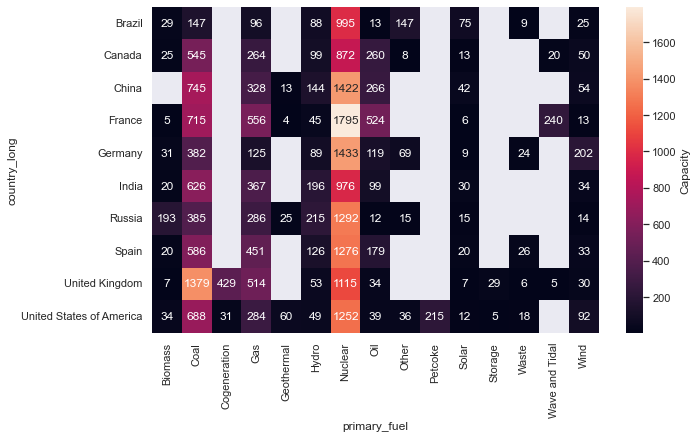

```python
sb.heatmap(mean_pf, annot= True, fmt = '.0f',cbar_kws= {'label': 'Capacity'} )
```

France and china has a high capacity on coal, gas and oil. And Brazil has it big one on nuclear, even that it has only 2 plants of it.

Here, I'm choosing only data with the most interesting primary_fuel categories:

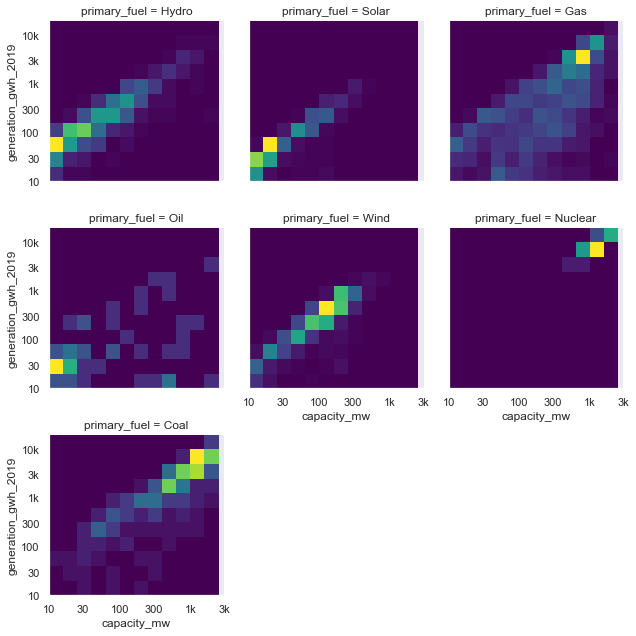

```python
# Make a function that plots hist2d with log scale on both axis
def heat_2d(x, y,**kwargs):
    bin_x = 10**np.arange(1, np.log10(plants.capacity_mw.max())+ .2,.2)
    bin_y = 10**np.arange(1,np.log10(plants.generation_gwh_2019.max())+ .3,.3)
    plt.hist2d(x, y, bins = [bin_x, bin_y], cmap = 'viridis')
    plt.xscale('log')
    plt.yscale('log')
    plt.xticks([10, 30, 100, 300, 1000, 3000], [10, 30, 100, 300, '1k', '3k'])
    plt.yticks([10, 30, 100, 300, 1000, 3000, 10000], [10, 30, 100, 300, '1k', '3k','10k'])
hists = sb.FacetGrid(data= plants[plants.primary_fuel.isin([ 'Nuclear','Oil', 'Gas', 'Coal', 'Solar', 'Wind', 'Hydro'])], col= 'primary_fuel', col_wrap= 3, palette = 'viridis_r')
hists.map(heat_2d, 'capacity_mw', 'generation_gwh_2019')
```

Most values of both variables in nuclear, coal, gas and wind are located on maximum upper right, where nuclear has the fewest number of plants limited in a small range of both variables. On reverse, the other categories have the lowest values, even that hydro has many other plants with higher values. It must be noted that even that most values of oil are small, there are some high values ranges with no regular form.

```python
plants_c1 = plants_c.loc[plants.primary_fuel.isin(['Solar', 'Hydro', 'Wind', 'Gas', 'Oil', 'Coal', 'Biomass'])]
plants_c2 = plants.loc[plants.country_long.isin(['United States of America', 'China', 'United Kingdom', 'France', 'Brazil'])]
plants_c2['commissioning_year'] = plants_c2.loc[plants_c2['commissioning_year'].notna()]['commissioning_year'].astype(int)
year_order = plants.groupby('commissioning_year')['capacity_mw'].mean().sort_index().index
```

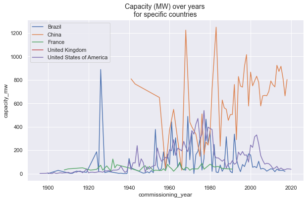

```python
sb.lineplot(data=plants_c2.loc[plants.country_long.isin(['United States of America', 'China', 'United Kingdom', 'France', 'Brazil'])]
            , x = 'commissioning_year', y = 'capacity_mw', hue = 'country_long', err_style=None)
plt.legend(loc= 'upper left')
plt.title('Capacity (MW) over years \nfor specific countries', fontsize=14)
```

The progression here is very relative. There is an obvious increasing in China with many rises and falls. Brazil has a big rise in 1928, and then it falls again and continues to increase relatively until the 2000's where it comes down again. There is not much going in France, it has almost stright progression.

Considering the number of plants is increasing, this could show us how much plants are they starting with a specific primary fuel that have even a high or low capacity. For example China might started more power plants with fuel like Nuclear, which has a high capacity average.

The UK data here is lost, there must be a missing records or some error.

Now, I'm doing the same thing as before but for each fuel category:

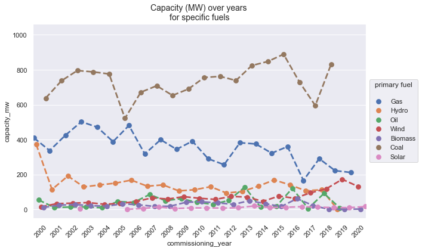

```python
#Starting from only 2000

plt.figure(figsize = [10, 6])

sb.pointplot(data = plants_c1, x = 'commissioning_year', y = 'capacity_mw', hue = 'primary_fuel',
             linestyles= '--', dodge= .9, order= years_id, errwidth= 0 )
plt.legend(loc = 'center left', bbox_to_anchor=(1, 0.5), title = 'primary fuel\n')
plt.xticks(rotation = 45);
plt.title('Capacity (MW) over years \nfor specific fuels', fontsize=14)
```

Generally, there is no real increasings; exculding coal, gas and wind, capacity of fuel categroies is stable with some small rises and falls. Gas seems to be decreasing, contrary to wind, and coal is also increasing relatively until 2016.

This progression might tell us the degree of fuel exploit technology devolopement, which require the answer of how much energy is being lost from plants operation?.

Nuclear fuel is missing in some years, so It's not involved in this plot.

### Were there any interesting or surprising interactions between features?

What make it interesting for the relation between capacity, countries and primary_fuel is that it could give us a simple glimpse of energy sources for each of these countries. As an example, the UK have a lack of sunlight in it's lands, that could reflect it's solar capacity.

For the capacity over time for some countries, we see that even the number of plants is increasing, capacity doesn't necessary have to be so. it might depend on having more plants using a fuel with high capacity over time, like nuclear energy.

`Note`:

Here is a simple source to compare between capacity and energy.

[click here](https://www.climatecouncil.org.au/resources/the-difference-between-installed-capacity-mw-and-energy-generation-mwh/)

```python
plants.to_csv('p_plants_clean.csv', index= False)
```